# Reproducible_Research_Assigment_2

Frolov Nikita

October 7, 2018

# Storm Data analysis with NOAA Storm Database

The basic goal of this assignment is to explore the NOAA Storm Database and answer some basic questions about severe weather events.

# Synopsis

**Summary of the analysis steps.**

1. **Downloading**: download the data and assign it to a variable.
2. **Processing**: process the data to answer two questions:
- Across the United States, which types of events (as indicated in the `EVTYPE` variable) are most harmful with respect to population health?
- Across the United States, which types of events have the greatest economic consequences?
3. **Analysis 1**: use `EVTYPE` variable to detect most harmful to population health event.
4. **Analysis 2**: use `EVTYPE` variable to detect which event has the greatest economic consequences.

# Data Pre-Processing

#### Dowloading and subsetting the data with required data only.

```r
if(!file.exists("stormData.csv.bz2")) {
  download.file("https://d396qusza40orc.cloudfront.net/repdata%2Fdata%2FStormData.csv.bz2",
  destfile = "stormData.csv.bz2")
}
dataNOAA <- read.csv(bzfile("stormData.csv.bz2"), sep=",", header=T)
dataNOAA <- dataNOAA[,c('EVTYPE','FATALITIES','INJURIES', 'PROPDMG', 'PROPDMGEXP', 'CROPDMG', 'CROPDMGEXP')]
```

#### Converting property and crop damage `H, K, M, B` indicators to calculated values stored at `PROPDMGVAL` and `CROPDMGVAL`.

```r
dataNOAA$PROPDMGVAL = 0
dataNOAA$CROPDMGVAL = 0
dataNOAA[dataNOAA$PROPDMGEXP == "H", ]$PROPDMGVAL = dataNOAA[dataNOAA$PROPDMGEXP == "H", ]$PROPDMG * 10^2
dataNOAA[dataNOAA$CROPDMGEXP == "H", ]$CROPDMGVAL = dataNOAA[dataNOAA$CROPDMGEXP == "H", ]$CROPDMG * 10^2
dataNOAA[dataNOAA$PROPDMGEXP == "K", ]$PROPDMGVAL = dataNOAA[dataNOAA$PROPDMGEXP == "K", ]$PROPDMG * 10^3
dataNOAA[dataNOAA$CROPDMGEXP == "K", ]$CROPDMGVAL = dataNOAA[dataNOAA$CROPDMGEXP == "K", ]$CROPDMG * 10^3
dataNOAA[dataNOAA$PROPDMGEXP == "M", ]$PROPDMGVAL = dataNOAA[dataNOAA$PROPDMGEXP == "M", ]$PROPDMG * 10^6
dataNOAA[dataNOAA$CROPDMGEXP == "M", ]$CROPDMGVAL = dataNOAA[dataNOAA$CROPDMGEXP == "M", ]$CROPDMG * 10^6
dataNOAA[dataNOAA$PROPDMGEXP == "B", ]$PROPDMGVAL = dataNOAA[dataNOAA$PROPDMGEXP == "B", ]$PROPDMG * 10^9
dataNOAA[dataNOAA$CROPDMGEXP == "B", ]$CROPDMGVAL = dataNOAA[dataNOAA$CROPDMGEXP == "B", ]$CROPDMG * 10^9
```

# Data Processing and Results

### Determining most harmfull events in respest to fatalities and injuries.

#### 5 most harmful events with respect to fatalities.

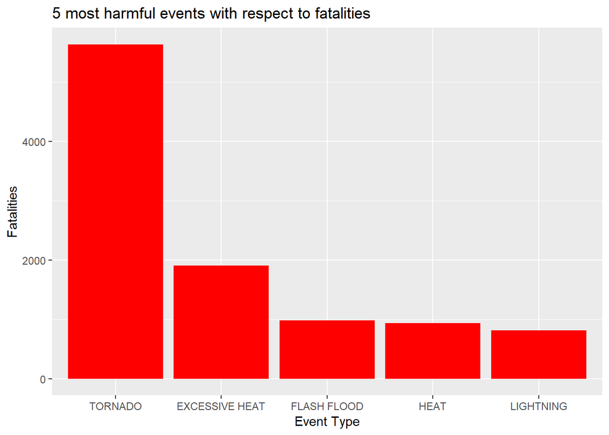

```r
library(ggplot2)
fatal <- aggregate(FATALITIES ~ EVTYPE, data=dataNOAA, sum)
fatalOrdered <- fatal[order(-fatal$FATALITIES), ][1:5, ]
ggplot(fatalOrdered, aes(x = factor(fatalOrdered$EVTYPE,
    levels = fatalOrdered$EVTYPE), y = FATALITIES)) +
    geom_bar(stat = "identity", fill = "red") +
    xlab("Event Type") + ylab("Fatalities") + ggtitle("5 most harmful events with respect to fatalities")
```

#### 5 most harmful events with respect to injuries.

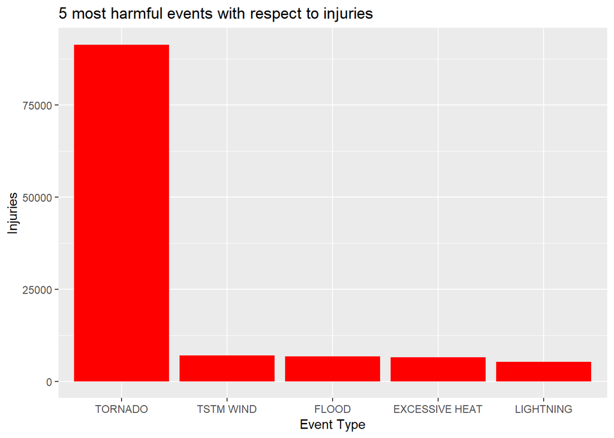

```r
library(ggplot2)
inj <- aggregate(INJURIES ~ EVTYPE, data=dataNOAA, sum)
injOrdered <- inj[order(-inj$INJURIES), ][1:5, ]
ggplot(injOrdered, aes(x = factor(injOrdered$EVTYPE,
    levels = injOrdered$EVTYPE), y = INJURIES)) +
    geom_bar(stat = "identity", fill = "red") +
    xlab("Event Type") + ylab("Injuries") + ggtitle("5 most harmful events with respect to injuries")
```

#### **According to the plots tornado is the most harmfull weather event with respect to both fatalities and injuries.**

### Determining most harmfull events in respest to economic consequences.

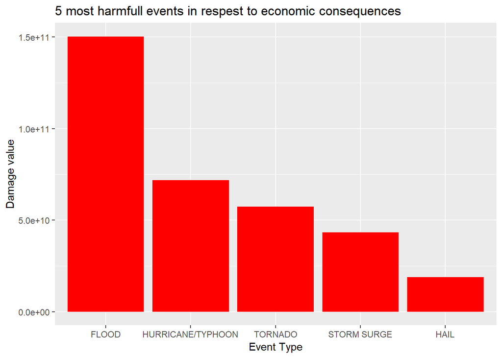

```r
library(ggplot2)
dmgs <- aggregate(PROPDMGVAL + CROPDMGVAL ~ EVTYPE, data=dataNOAA, sum)
names(dmgs) = c("EVTYPE", "TTLVAL")
dmgsOrdered <- dmgs[order(-dmgs$TTLVAL), ][1:5, ]
ggplot(dmgsOrdered, aes(x = factor(dmgsOrdered$EVTYPE,
    levels = dmgsOrdered$EVTYPE), y = TTLVAL)) +
    geom_bar(stat = "identity", fill = "red") +
    xlab("Event Type") + ylab("Damage value") + ggtitle("5 most harmfull events in respest to economic consequences")
```

#### **According to the plot flood is the most harmfull weather event with respect to economic consequences.**